# Polynomial Regression

## Vip

The next visualisations will be of the Vip dataset

*Column heading Parameter description Unit Interval Dataset name Type Comments Data collection*

[figure not shown]

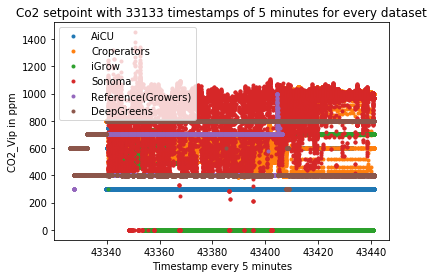

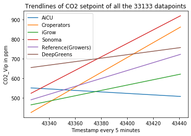

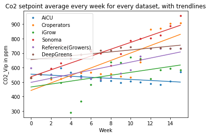

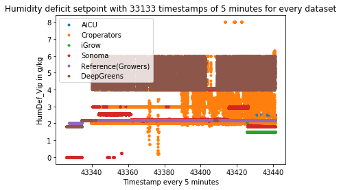

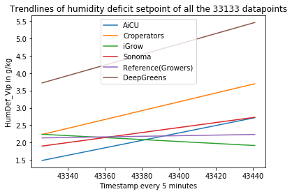

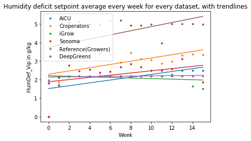

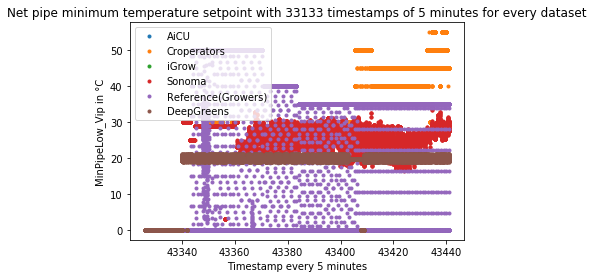

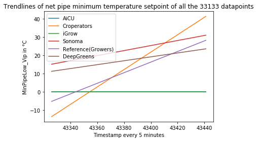

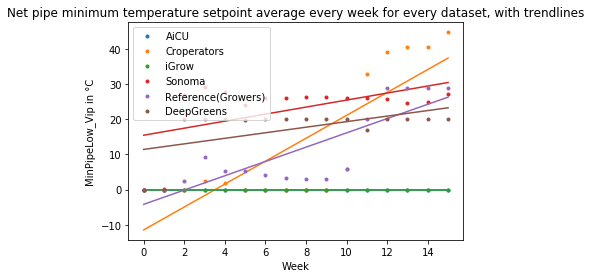

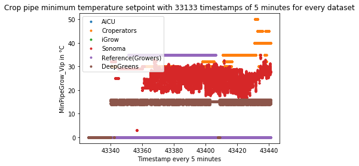

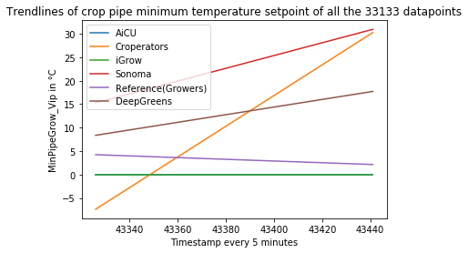

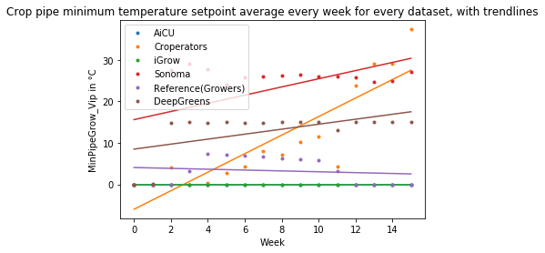

# Weekly average

# Polynomial fitting

```
Which degree of polynomial fitting would you like?
3
Tair
```

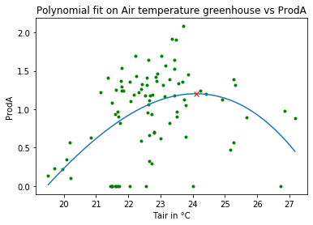

```
The optimal value(s) according to a polynomial
with a degree of 3: 24.099045870876175.
RHair
```

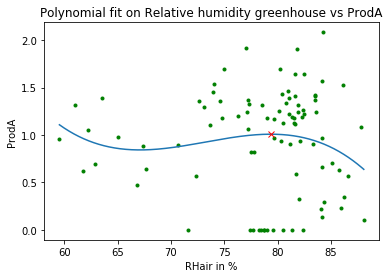

```
The optimal value(s) according to a polynomial
with a degree of 3: 79.35279458644595.
CO2air
```

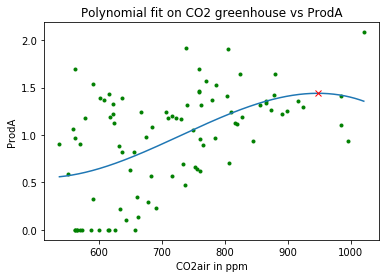

```
The optimal value(s) according to a polynomial
with a degree of 3: 947.475264901824.
HumDef
```

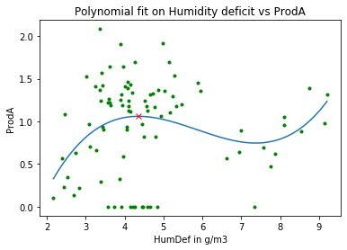

```
The optimal value(s) according to a polynomial
with a degree of 3: 4.35333481046694.
PipeLow
```

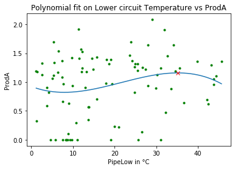

```
The optimal value(s) according to a polynomial
with a degree of 3: 35.119274508147164.
PipeGrow
```

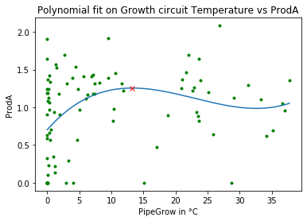

```
The optimal value(s) according to a polynomial
with a degree of 3: 13.256350546036481.
Tair
```

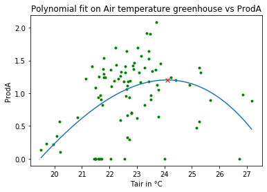

```
The optimal value(s) according to a polynomial
with a degree of 3: 24.099045870876175.
RHair
```

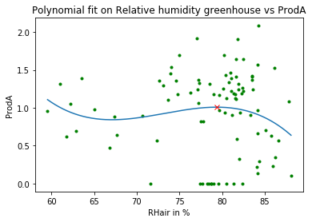

```
The optimal value(s) according to a polynomial
with a degree of 3: 79.35279458644595.
CO2air
```

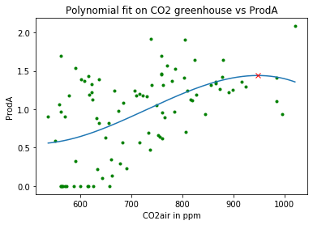

```
The optimal value(s) according to a polynomial
with a degree of 3: 947.475264901824.
HumDef
```

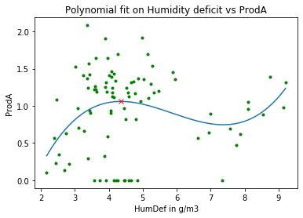

```
The optimal value(s) according to a polynomial
with a degree of 3: 4.35333481046694.
PipeLow
```

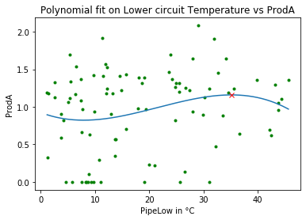

```
The optimal value(s) according to a polynomial
with a degree of 3: 35.119274508147164.
PipeGrow
```

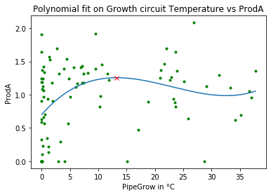

```
The optimal value(s) according to a polynomial
with a degree of 3: 13.256350546036481.
```

# Results

*More results can be found in the README.md and on the webpage mentioned in the start of this file: readmees.github.io/polynomial_fit.html.*

As you can see in the following figure, according to Zheng et al. (2018) the optimal CO growth for three perennial grass species is around 915 ppm. If you fit an 3rd degree polynomial on the automonous greenhouse challenge data you will get a simulair result, +- 947.475264901824 ppm (see figure 2)

[figure not shown]

Figure 1: Zheng, Y., Li, F., Hao, L., Shedayi, A. A., Guo, L., Ma, C., ... & Xu, M. (2018). The optimal CO 2 concentrations for the growth of three perennial grass species. BMC plant biology, 18(1), 27.

[figure not shown]

Figure 2: Automonous greenhouse challenge data